# Phylogeny and Species Trait Effects on Detectability

Peter Solymos

2017-09-12

## Introduction

This document is a supporting material for the manuscript entitled *Phylogeny and species traits predict songbird detectability* by Peter Solymos, Steven M. Matsuoka, Diana Stralberg, Erin M. Bayne, and Nicole K. S. Barker.

The **lhreg** R package contains the (1) data, (2) analysis code used in the manuscript, and (3) code required to summarize the results and produce tables and figures.

The R package is hosted on [GitHub](https://github.com/borealbirds/lhreg), Please submit issues [here](https://github.com/borealbirds/lhreg/issues).

The package is archived on Zenodo under the DOI [10.5281/zenodo.574886](https://zenodo.org/badge/latestdoi/90998177).

The package can be installed as:

```r
devtools::install_github("borealbirds/lhreg")
```

The present document can be viewed as:

```r
vignette(topic = "lhreg", package = "lhreg")
```

## Components of detectability

The manuscript refer to singing rate ($SR$, here we also refer to it as `phi`) and detection distance ($DD$, which we refer to as `tau`), which are linked to detectability as explained in this section. Solymos et al. (2013, DOI 10.1111/2041-210X.12106) describes the mathematical details of singing rate estimation based on removal sampling and effective detection distance estimation via distance sampling. These quantities define the probability of individuals of the species are available for sampling given presence (often referred to as availability, $p$), and the probability that an individual of that species is being detected given it produces a cue (often referred to as perceptibility, $q$).

$p=1-exp(-t~SR)$, where $t$ is the duration of the counting period. $q=DD^2~(1-exp(-r^2 / DD^2))~/~r^2$, where $r$ is the rounting radius (i.e. not counting individuals beyond this distance from the observer). Probability of detection is the produc to the two components: $pq$.

## Data and data processing

### Variables

The `lhreg_data` is a data frame with all response variables (`logphi` is log singing rate, `logtau` is log detection distance) and trait values (unmodified and transformed versions).

```r
library(lhreg)
data(lhreg_data)
str(lhreg_data)
```

```
## 'data.frame':    141 obs. of  24 variables:
##  $ spp            : Factor w/ 141 levels "ALFL","AMCR",..: 1 2 3 4 5 6 7 8 9 10 ...
##  $ scientific_name: Factor w/ 141 levels "Actitis macularius",..: 37 32 115 5 104 128 116 78 91 50 ...
##  $ common_name    : Factor w/ 141 levels "Alder Flycatcher",..: 1 2 3 4 5 6 8 7 10 9 ...
##  $ WJSpecID       : int  6038 8093 12332 11885 12720 9007 12559 969 10052 13379 ...
##  $ Scientific     : Factor w/ 141 levels "Actitis macularius",..: 51 32 15 5 104 122 110 89 100 62 ...
##  $ Scientific2    : Factor w/ 141 levels "Actitis macularius",..: 51 32 15 5 104 122 110 89 100 62 ...
##  $ logphi         : num  -1.14 -1.36 -2.18 -1.67 -1.17 ...
##  $ logtau         : num  -0.1984 0.6127 -0.2329 0.0905 -0.5379 ...
##  $ logphiSE       : num  0.0147 0.0157 0.0725 0.1209 0.0142 ...
##  $ logtauSE       : num  0.00489 0.00553 0.00456 0.1151 0.00474 ...
##  $ mass           : num  12.7 448.76 12.79 20.68 8.24 ...
##  $ logmass        : num  2.54 6.11 2.55 3.03 2.11 ...
##  $ MaxFreqkHz     : num  6.4 1.62 8.25 8 8 4 6.5 3.2 7 3.9 ...
##  $ Migr           : Factor w/ 4 levels "Neotropical migrant",..: 1 4 4 1 1 4 4 3 1 1 ...
##  $ Nesthm         : num  1 8 2 0 2 2 0 5.6 3 8 ...
##  $ habitat        : Factor w/ 9 levels "Forest","Grassland",..: 7 6 6 2 1 6 6 1 3 6 ...
##  $ food           : Factor w/ 8 levels "Fish","Fruit",..: 3 5 7 3 3 3 7 3 3 3 ...
##  $ behavior       : Factor w/ 8 levels "Aerial Dive",..: 4 6 5 6 5 6 6 3 2 5 ...
##  $ Mig            : Factor w/ 3 levels "LD","WR","SD": 1 3 3 1 1 3 3 2 1 1 ...
##  $ Mig2           : Factor w/ 2 levels "M","W": 1 1 1 1 1 1 1 2 1 1 ...
##  $ Hab2           : Factor w/ 2 levels "Closed","Open": 2 1 1 2 1 1 1 1 2 1 ...
##  $ Hab3           : Factor w/ 3 levels "For","Open","Wood": 2 3 3 2 1 3 3 1 2 3 ...
##  $ Hab4           : Factor w/ 4 levels "For","Open","Wet",..: 2 4 4 2 1 4 4 1 3 4 ...
##  $ xMaxFreqkHz    : num  0.64 0.162 0.825 0.8 0.8 0.4 0.65 0.32 0.7 0.39 ...
```

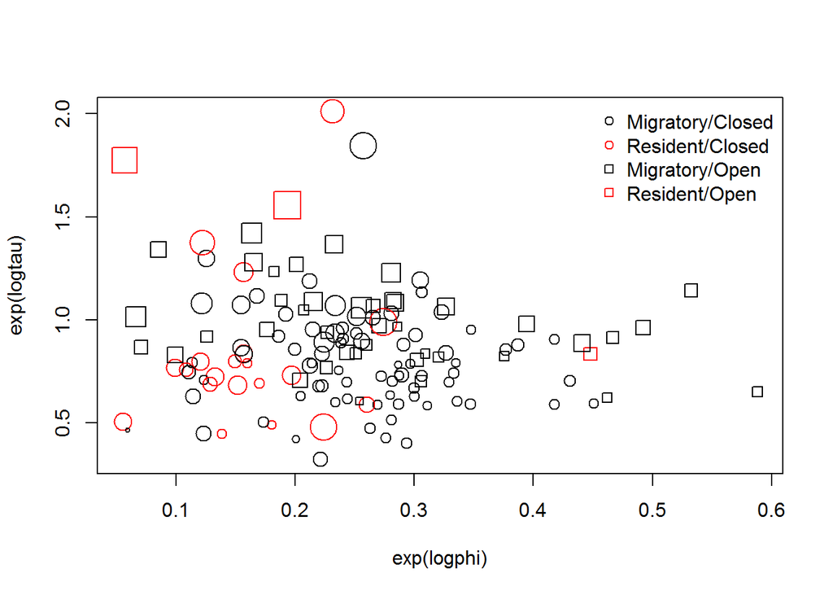

```r
with(lhreg_data, plot(exp(logphi), exp(logtau),
    cex=logmass*0.5, col=Mig2, pch=c(21, 22)[Hab2]))
legend("topright", bty="n", pch=c(21, 21, 22, 22), col=c(1,2,1,2),
    legend=c("Migratory/Closed", "Resident/Closed",
    "Migratory/Open", "Resident/Open"))
```

Here is a list of species used in the manuscript:

| common_name | scientific_name | spp |
| --- | --- | --- |
| Alder Flycatcher | Empidonax alnorum | ALFL |
| American Crow | Corvus brachyrhynchos | AMCR |
| American Goldfinch | Spinus tristis | AMGO |
| American Pipit | Anthus rubescens | AMPI |
| American Redstart | Setophaga ruticilla | AMRE |
| American Robin | Turdus migratorius | AMRO |
| American Tree Sparrow | Spizella arborea | ATSP |
| American Three-toed Woodpecker | Picoides dorsalis | ATTW |
| Bank Swallow | Riparia riparia | BANS |
| Baltimore Oriole | Icterus galbula | BAOR |
| Barn Swallow | Hirundo rustica | BARS |
| Black-and-white Warbler | Mniotilta varia | BAWW |
| Black-billed Cuckoo | Coccyzus erythropthalmus | BBCU |
| Black-billed Magpie | Pica hudsonia | BBMA |
| Bay-breasted Warbler | Setophaga castanea | BBWA |
| Black-backed Woodpecker | Picoides arcticus | BBWO |
| Black-capped Chickadee | Poecile atricapillus | BCCH |
| Belted Kingfisher | Megaceryle alcyon | BEKI |
| Brown-headed Cowbird | Molothrus ater | BHCO |
| Blue-headed Vireo | Vireo solitarius | BHVI |
| Blackburnian Warbler | Setophaga fusca | BLBW |
| Blue Jay | Cyanocitta cristata | BLJA |
| Blackpoll Warbler | Setophaga striata | BLPW |
| Boreal Chickadee | Poecile hudsonicus | BOCH |
| Bohemian Waxwing | Bombycilla garrulus | BOWA |
| Brewer’s Blackbird | Euphagus cyanocephalus | BRBL |
| Brown Creeper | Certhia americana | BRCR |
| Brown Thrasher | Toxostoma rufum | BRTH |
| Black-throated Blue Warbler | Setophaga caerulescens | BTBW |
| Black-throated Green Warbler | Setophaga virens | BTNW |

[output cut: 111 more lines]

Here are the response variables and their standard errors:

| common_name | SR | logphi | logphiSE | DD | logtau | logtauSE |
| --- | --- | --- | --- | --- | --- | --- |
| Alder Flycatcher | 0.320 | -1.138 | 0.015 | 82.006 | -0.198 | 0.005 |
| American Crow | 0.257 | -1.358 | 0.016 | 184.538 | 0.613 | 0.006 |
| American Goldfinch | 0.114 | -2.175 | 0.073 | 79.222 | -0.233 | 0.005 |
| American Pipit | 0.189 | -1.669 | 0.121 | 109.467 | 0.090 | 0.115 |
| American Redstart | 0.311 | -1.169 | 0.014 | 58.398 | -0.538 | 0.005 |
| American Robin | 0.233 | -1.456 | 0.013 | 93.723 | -0.065 | 0.003 |
| American Tree Sparrow | 0.239 | -1.430 | 0.042 | 96.194 | -0.039 | 0.037 |
| American Three-toed Woodpecker | 0.157 | -1.852 | 0.119 | 83.733 | -0.178 | 0.024 |
| Bank Swallow | 0.207 | -1.573 | 0.141 | 104.713 | 0.046 | 0.009 |
| Baltimore Oriole | 0.223 | -1.502 | 0.078 | 83.612 | -0.179 | 0.010 |
| Barn Swallow | 0.126 | -2.072 | 0.176 | 91.939 | -0.084 | 0.006 |
| Black-and-white Warbler | 0.244 | -1.411 | 0.019 | 61.796 | -0.481 | 0.006 |
| Black-billed Cuckoo | 0.126 | -2.075 | 0.146 | 129.832 | 0.261 | 0.026 |
| Black-billed Magpie | 0.231 | -1.464 | 0.045 | 201.149 | 0.699 | 0.091 |
| Bay-breasted Warbler | 0.293 | -1.226 | 0.030 | 40.285 | -0.909 | 0.009 |
| Black-backed Woodpecker | 0.197 | -1.624 | 0.102 | 73.152 | -0.313 | 0.025 |
| Black-capped Chickadee | 0.170 | -1.773 | 0.024 | 69.245 | -0.368 | 0.004 |
| Belted Kingfisher | 0.066 | -2.714 | 0.501 | 101.418 | 0.014 | 0.024 |
| Brown-headed Cowbird | 0.204 | -1.588 | 0.031 | 70.703 | -0.347 | 0.007 |
| Blue-headed Vireo | 0.220 | -1.514 | 0.029 | 67.926 | -0.387 | 0.007 |
| Blackburnian Warbler | 0.269 | -1.312 | 0.020 | 58.645 | -0.534 | 0.008 |
| Blue Jay | 0.157 | -1.853 | 0.021 | 123.055 | 0.207 | 0.005 |
| Blackpoll Warbler | 0.263 | -1.336 | 0.065 | 47.355 | -0.747 | 0.015 |
| Boreal Chickadee | 0.139 | -1.974 | 0.059 | 44.585 | -0.808 | 0.010 |
| Bohemian Waxwing | 0.055 | -2.892 | 0.595 | 50.822 | -0.677 | 0.036 |
| Brewer’s Blackbird | 0.282 | -1.265 | 0.065 | 109.238 | 0.088 | 0.037 |
| Brown Creeper | 0.180 | -1.713 | 0.039 | 49.242 | -0.708 | 0.009 |
| Brown Thrasher | 0.284 | -1.259 | 0.067 | 108.198 | 0.079 | 0.019 |
| Black-throated Blue Warbler | 0.243 | -1.414 | 0.049 | 69.802 | -0.360 | 0.008 |
| Black-throated Green Warbler | 0.287 | -1.247 | 0.014 | 72.827 | -0.317 | 0.004 |

[output cut: 111 more lines]

Other trait variables used are predictors:

| common_name | mass | MaxFreqkHz | Mig2 | Hab2 | Nesthm |
| --- | --- | --- | --- | --- | --- |
| Alder Flycatcher | 12.70 | 6.40 | M | Open | 1.0 |
| American Crow | 448.76 | 1.62 | M | Closed | 8.0 |
| American Goldfinch | 12.79 | 8.25 | M | Closed | 2.0 |
| American Pipit | 20.68 | 8.00 | M | Open | 0.0 |
| American Redstart | 8.24 | 8.00 | M | Closed | 2.0 |
| American Robin | 78.50 | 4.00 | M | Closed | 2.0 |
| American Tree Sparrow | 17.83 | 6.50 | M | Closed | 0.0 |
| American Three-toed Woodpecker | 55.05 | 3.20 | W | Closed | 5.6 |
| Bank Swallow | 12.68 | 7.00 | M | Open | 3.0 |
| Baltimore Oriole | 32.83 | 3.90 | M | Closed | 8.0 |
| Barn Swallow | 17.91 | 7.00 | M | Open | 2.0 |
| Black-and-white Warbler | 10.90 | 9.00 | M | Closed | 0.0 |
| Black-billed Cuckoo | 50.90 | 2.50 | M | Closed | 1.0 |
| Black-billed Magpie | 217.48 | 6.00 | W | Closed | 4.0 |
| Bay-breasted Warbler | 11.80 | 9.00 | M | Closed | 4.0 |
| Black-backed Woodpecker | 69.24 | 12.00 | W | Closed | 4.0 |
| Black-capped Chickadee | 10.80 | 3.20 | W | Closed | 2.0 |
| Belted Kingfisher | 148.00 | 9.00 | M | Open | 4.0 |
| Brown-headed Cowbird | 40.26 | 12.00 | M | Open | 2.0 |
| Blue-headed Vireo | 15.30 | 6.00 | M | Closed | 3.0 |
| Blackburnian Warbler | 9.74 | 11.50 | M | Closed | 9.0 |
| Blue Jay | 88.00 | 3.20 | W | Closed | 4.0 |
| Blackpoll Warbler | 11.84 | 10.22 | M | Closed | 2.0 |
| Boreal Chickadee | 9.80 | 7.70 | W | Closed | 3.0 |
| Bohemian Waxwing | 54.41 | 10.00 | W | Closed | 8.0 |
| Brewer’s Blackbird | 62.48 | 6.70 | M | Open | 0.0 |
| Brown Creeper | 8.10 | 8.50 | W | Closed | 3.0 |
| Brown Thrasher | 68.80 | 6.50 | M | Open | 1.0 |
| Black-throated Blue Warbler | 10.14 | 6.00 | M | Closed | 0.0 |
| Black-throated Green Warbler | 8.69 | 8.00 | M | Closed | 5.0 |

[output cut: 111 more lines]

### Phylogenetic correlations

This code was used to average the 1000 pseudo-posterior trees from Jetz et al. (2012) with Ericson backbone to represent the phylogenetic relationships among the species:

```r
library(ape)
mph <- read.nexus("11960.tre") # 1000 trees with Ericson backbone
lhreg_tree <- consensus(mph)
table(sapply(mph, function(z) length(z$tip.label)))
CORR <- TRUE
vv <- list()
vv[[1]] <- vcv(mph[[1]], corr=CORR)
for (i in 2:length(mph)) {
    v <- vcv(mph[[i]], corr=CORR)
    v <- v[rownames(vv[[1]]), colnames(vv[[1]])]
    vv[[i]] <- v
}
vvv <- v
for (i in 1:length(v)) {
    vvv[i] <- mean(sapply(vv, function(z) z[i]))
}
spp <- intersect(rownames(lhreg_data), rownames(vvv))
vvv <- vvv[spp,spp]
cor_matrix <- as.matrix(nearPD(vvv, corr=TRUE)$mat)
```

The object `cor_matrix` is part of the **lhreg** package, relative phylogenies can be reconstructed from it:

```r
library(ape)
data(cor_matrix)
data(lhreg_tree)
str(cor_matrix)
```

```
##  num [1:141, 1:141] 1 0.33 0.33 0.33 0.33 ...
##  - attr(*, "dimnames")=List of 2
##   ..$ : chr [1:141] "Empidonax_alnorum" "Corvus_brachyrhynchos" "Carduelis_tristis" "Anthus_rubescens" ...
##   ..$ : chr [1:141] "Empidonax_alnorum" "Corvus_brachyrhynchos" "Carduelis_tristis" "Anthus_rubescens" ...
```

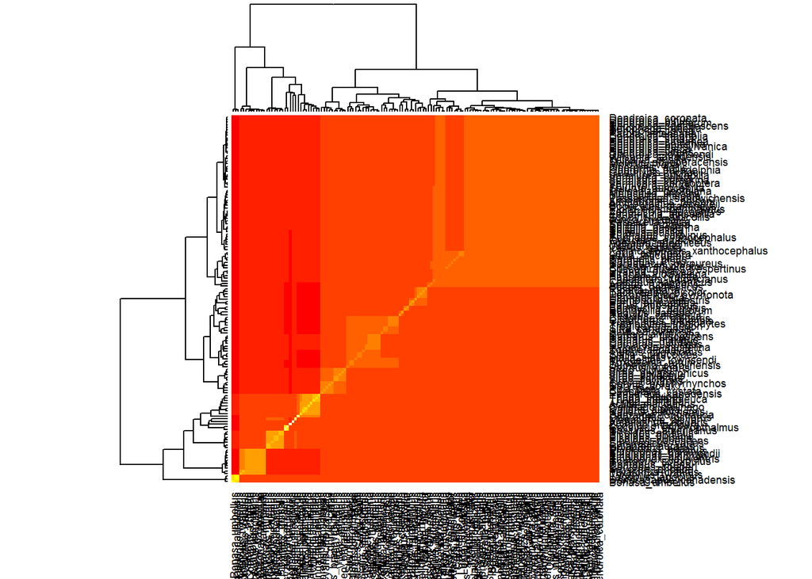

```r
heatmap(cor_matrix)
```

## Analysis

Linear model were used to screen trait variables, so that we compared that *full* model with the intercept only *null* model, with or without phylogenetic correlation.

### Variable screening for SR

```r
library(lhreg)
data(lhreg_data)
data(cor_matrix)

y <- lhreg_data$logphi
m4 <- lm(y ~ logmass + Mig2 + Nesthm + xMaxFreqkHz + Hab4, lhreg_data)
m3 <- lm(y ~ logmass + Mig2 + Nesthm + xMaxFreqkHz + Hab3, lhreg_data)
m2 <- lm(y ~ logmass + Mig2 + Nesthm + xMaxFreqkHz + Hab2, lhreg_data)
m4s <- step(m4, trace=0)
m3s <- step(m3, trace=0)
m2s <- step(m2, trace=0)
AIC(m4,m3,m2,m4s,m3s,m2s)
```

```
##     df      AIC
## m4   9 159.2927
## m3   8 159.9963
## m2   7 159.5903
## m4s  5 157.4045
## m3s  5 157.4045
## m2s  5 157.4045
```

```r
summary(m2s)
```

```
##
## Call:
## lm(formula = y ~ Mig2 + Nesthm + xMaxFreqkHz, data = lhreg_data)
##
## Residuals:
##      Min       1Q   Median       3Q      Max
## -1.35699 -0.17658  0.05151  0.23901  1.06279
##
## Coefficients:
##             Estimate Std. Error t value Pr(>|t|)
## (Intercept) -1.60265    0.11180  -14.34  < 2e-16 ***
## Mig2W       -0.36778    0.09966   -3.69 0.000322 ***
## Nesthm      -0.01553    0.01022   -1.52 0.130918
## xMaxFreqkHz  0.33360    0.14825    2.25 0.026031 *
## ---
## Signif. codes:  0 '***' 0.001 '**' 0.01 '*' 0.05 '.' 0.1 ' ' 1
##
## Residual standard error: 0.414 on 137 degrees of freedom
## Multiple R-squared:  0.1833, Adjusted R-squared:  0.1654
## F-statistic: 10.25 on 3 and 137 DF,  p-value: 3.916e-06
```

```r
mp <- update(m2s, .~.-Nesthm)

amp <- anova(mp)
round(structure(100 * amp[,"Sum Sq"] / sum(amp[,"Sum Sq"]),
    names=rownames(amp)), 1)
```

```
##        Mig2 xMaxFreqkHz   Residuals
##        13.4         3.6        83.0
```

```r
mp0 <- lm(y ~ 1)
summary(mp0) # null model for SR
```

```
##
## Call:
## lm(formula = y ~ 1)
##
## Residuals:
##      Min       1Q   Median       3Q      Max
## -1.39617 -0.23821  0.06881  0.28168  0.96531
##
## Coefficients:
##             Estimate Std. Error t value Pr(>|t|)
## (Intercept) -1.49625    0.03817   -39.2   <2e-16 ***
## ---
## Signif. codes:  0 '***' 0.001 '**' 0.01 '*' 0.05 '.' 0.1 ' ' 1
##
## Residual standard error: 0.4532 on 140 degrees of freedom
```

```r
summary(mp) # full model for SR
```

```
##
## Call:
## lm(formula = y ~ Mig2 + xMaxFreqkHz, data = lhreg_data)
##
## Residuals:
##      Min       1Q   Median       3Q      Max
## -1.37585 -0.18443  0.05156  0.26123  1.08980
##
## Coefficients:
##             Estimate Std. Error t value Pr(>|t|)
## (Intercept)  -1.6619     0.1053 -15.783  < 2e-16 ***
## Mig2W        -0.4108     0.0960  -4.280 3.48e-05 ***
## xMaxFreqkHz   0.3599     0.1479   2.432   0.0163 *
## ---
## Signif. codes:  0 '***' 0.001 '**' 0.01 '*' 0.05 '.' 0.1 ' ' 1
##
## Residual standard error: 0.416 on 138 degrees of freedom
## Multiple R-squared:  0.1696, Adjusted R-squared:  0.1575
## F-statistic: 14.09 on 2 and 138 DF,  p-value: 2.705e-06
```

```r
## evaluating interactions
mpx <- lm(y ~ logmass + Mig2 + Nesthm + xMaxFreqkHz + Hab2 +
    logmass:xMaxFreqkHz + Hab2:xMaxFreqkHz, lhreg_data)
mpx2 <- step(mpx)
```

```
## Start:  AIC=-248.78
## y ~ logmass + Mig2 + Nesthm + xMaxFreqkHz + Hab2 + logmass:xMaxFreqkHz +
##     Hab2:xMaxFreqkHz
##
##                       Df Sum of Sq    RSS     AIC
## <none>                             21.561 -248.78
## - xMaxFreqkHz:Hab2     1   0.32411 21.886 -248.67
## - Nesthm               1   0.49472 22.056 -247.58
## - Mig2                 1   0.99609 22.558 -244.41
## - logmass:xMaxFreqkHz  1   1.49463 23.056 -241.33
```

```r
summary(mpx2)
```

```
##
## Call:
## lm(formula = y ~ logmass + Mig2 + Nesthm + xMaxFreqkHz + Hab2 +
##     logmass:xMaxFreqkHz + Hab2:xMaxFreqkHz, data = lhreg_data)
##
## Residuals:
##      Min       1Q   Median       3Q      Max
## -1.42164 -0.17969  0.02572  0.24807  1.03521
##
## Coefficients:
##                      Estimate Std. Error t value Pr(>|t|)
## (Intercept)          -2.28929    0.37591  -6.090 1.14e-08 ***
## logmass               0.21429    0.09721   2.204  0.02922 *
## Mig2W                -0.26467    0.10677  -2.479  0.01444 *
## Nesthm               -0.01806    0.01034  -1.747  0.08297 .
## xMaxFreqkHz           1.73042    0.54335   3.185  0.00181 **
## Hab2Open             -0.24608    0.23044  -1.068  0.28751
## logmass:xMaxFreqkHz  -0.47046    0.15494  -3.036  0.00288 **
## xMaxFreqkHz:Hab2Open  0.47503    0.33596   1.414  0.15972
## ---
## Signif. codes:  0 '***' 0.001 '**' 0.01 '*' 0.05 '.' 0.1 ' ' 1
##
## Residual standard error: 0.4026 on 133 degrees of freedom
## Multiple R-squared:  0.2502, Adjusted R-squared:  0.2107
## F-statistic: 6.339 on 7 and 133 DF,  p-value: 1.962e-06
```

### Variable screening for DD

```r
y <- lhreg_data$logtau
m4 <- lm(y ~ logmass + Mig2 + Nesthm + xMaxFreqkHz + Hab4, lhreg_data)
m3 <- lm(y ~ logmass + Mig2 + Nesthm + xMaxFreqkHz + Hab3, lhreg_data)
m2 <- lm(y ~ logmass + Mig2 + Nesthm + xMaxFreqkHz + Hab2, lhreg_data)
m4s <- step(m4, trace=0)
m3s <- step(m3, trace=0)
m2s <- step(m2, trace=0)
AIC(m4,m3,m2,m4s,m3s,m2s)
```

```
##     df      AIC
## m4   9 -1.18506
## m3   8 -3.17346
## m2   7 -5.16348
## m4s  9 -1.18506
## m3s  8 -3.17346
## m2s  7 -5.16348
```

```r
summary(m2s)
```

```
##
## Call:
## lm(formula = y ~ logmass + Mig2 + Nesthm + xMaxFreqkHz + Hab2,
##     data = lhreg_data)
##
## Residuals:
##      Min       1Q   Median       3Q      Max
## -0.97677 -0.11551 -0.00027  0.15237  0.71312
##
## Coefficients:
##              Estimate Std. Error t value Pr(>|t|)
## (Intercept) -0.557121   0.113501  -4.909 2.60e-06 ***
## logmass      0.160044   0.023038   6.947 1.44e-10 ***
## Mig2W       -0.142660   0.060505  -2.358  0.01982 *
## Nesthm      -0.008508   0.005919  -1.437  0.15297
## xMaxFreqkHz -0.236341   0.091005  -2.597  0.01045 *
## Hab2Open     0.133672   0.046257   2.890  0.00449 **
## ---
## Signif. codes:  0 '***' 0.001 '**' 0.01 '*' 0.05 '.' 0.1 ' ' 1
##
## Residual standard error: 0.231 on 135 degrees of freedom
## Multiple R-squared:  0.4701, Adjusted R-squared:  0.4505
## F-statistic: 23.95 on 5 and 135 DF,  p-value: < 2.2e-16
```

```r
mt <- update(m2s, .~.-Nesthm)

amt <- anova(mt)
round(structure(100 * amt[,"Sum Sq"] / sum(amt[,"Sum Sq"]),
    names=rownames(amt)), 1)
```

```
##     logmass        Mig2 xMaxFreqkHz        Hab2   Residuals
##        34.2         5.8         1.8         4.4        53.8
```

```r
mt0 <- lm(y ~ 1)
summary(mp0) # null model for DD
```

```
##
## Call:
## lm(formula = y ~ 1)
##
## Residuals:
##      Min       1Q   Median       3Q      Max
## -1.39617 -0.23821  0.06881  0.28168  0.96531
##
## Coefficients:
##             Estimate Std. Error t value Pr(>|t|)
## (Intercept) -1.49625    0.03817   -39.2   <2e-16 ***
## ---
## Signif. codes:  0 '***' 0.001 '**' 0.01 '*' 0.05 '.' 0.1 ' ' 1
##
## Residual standard error: 0.4532 on 140 degrees of freedom
```

```r
summary(mp) # full model for DD
```

```
##
## Call:
## lm(formula = y ~ Mig2 + xMaxFreqkHz, data = lhreg_data)
##
## Residuals:
##      Min       1Q   Median       3Q      Max
## -1.37585 -0.18443  0.05156  0.26123  1.08980
##
## Coefficients:
##             Estimate Std. Error t value Pr(>|t|)
## (Intercept)  -1.6619     0.1053 -15.783  < 2e-16 ***
## Mig2W        -0.4108     0.0960  -4.280 3.48e-05 ***
## xMaxFreqkHz   0.3599     0.1479   2.432   0.0163 *
## ---
## Signif. codes:  0 '***' 0.001 '**' 0.01 '*' 0.05 '.' 0.1 ' ' 1
##
## Residual standard error: 0.416 on 138 degrees of freedom
## Multiple R-squared:  0.1696, Adjusted R-squared:  0.1575
## F-statistic: 14.09 on 2 and 138 DF,  p-value: 2.705e-06
```

```r
## evaluating interactions
mtx <- lm(y ~ logmass + Mig2 + Nesthm + xMaxFreqkHz + Hab2 +
    logmass:xMaxFreqkHz + Hab2:xMaxFreqkHz, lhreg_data)
mtx2 <- step(mtx)
```

```
## Start:  AIC=-403.35
## y ~ logmass + Mig2 + Nesthm + xMaxFreqkHz + Hab2 + logmass:xMaxFreqkHz +
##     Hab2:xMaxFreqkHz
##
##                       Df Sum of Sq    RSS     AIC
## - logmass:xMaxFreqkHz  1  0.000128 7.2044 -405.34
## - xMaxFreqkHz:Hab2     1  0.002181 7.2064 -405.30
## <none>                             7.2042 -403.35
## - Nesthm               1  0.108346 7.3126 -403.24
## - Mig2                 1  0.290512 7.4947 -399.77
##
## Step:  AIC=-405.34
## y ~ logmass + Mig2 + Nesthm + xMaxFreqkHz + Hab2 + xMaxFreqkHz:Hab2
##
##                    Df Sum of Sq    RSS     AIC
## - xMaxFreqkHz:Hab2  1   0.00206 7.2064 -407.30
## <none>                          7.2044 -405.34
## - Nesthm            1   0.10919 7.3135 -405.22
## - Mig2              1   0.29587 7.5002 -401.67
## - logmass           1   2.57629 9.7806 -364.24
##
## Step:  AIC=-407.3
## y ~ logmass + Mig2 + Nesthm + xMaxFreqkHz + Hab2
##
##               Df Sum of Sq    RSS     AIC
## <none>                     7.2064 -407.30
## - Nesthm       1   0.11026 7.3167 -407.16
## - Mig2         1   0.29676 7.5032 -403.61
## - xMaxFreqkHz  1   0.36003 7.5664 -402.43
## - Hab2         1   0.44576 7.6522 -400.84
## - logmass      1   2.57607 9.7825 -366.21
```

```r
summary(mtx2)
```

```
##
## Call:
## lm(formula = y ~ logmass + Mig2 + Nesthm + xMaxFreqkHz + Hab2,
##     data = lhreg_data)
##
## Residuals:
##      Min       1Q   Median       3Q      Max
## -0.97677 -0.11551 -0.00027  0.15237  0.71312
##
## Coefficients:
##              Estimate Std. Error t value Pr(>|t|)
## (Intercept) -0.557121   0.113501  -4.909 2.60e-06 ***
## logmass      0.160044   0.023038   6.947 1.44e-10 ***
## Mig2W       -0.142660   0.060505  -2.358  0.01982 *
## Nesthm      -0.008508   0.005919  -1.437  0.15297
## xMaxFreqkHz -0.236341   0.091005  -2.597  0.01045 *
## Hab2Open     0.133672   0.046257   2.890  0.00449 **
## ---
## Signif. codes:  0 '***' 0.001 '**' 0.01 '*' 0.05 '.' 0.1 ' ' 1
##
## Residual standard error: 0.231 on 135 degrees of freedom
## Multiple R-squared:  0.4701, Adjusted R-squared:  0.4505
## F-statistic: 23.95 on 5 and 135 DF,  p-value: < 2.2e-16
```

### Mixed model selection

The following models were compared, the prefix `t` and `p` indicates `tau` (detection distance) and `phi` (singing rate):

1. `M00` as null model $M_{00}$,
2. `Ml0` as phylogeny-only model $M_{\lambda0}$,
3. `M0b` as trait-only model $M_{0\beta}$,
4. `Mlb` as combined model $M_{\lambda\beta}$.

```r
met <- "DE" # can use "SANN", "Nelder-Mead" is quickest
x <- lhreg_data
vc <- cor_matrix

## model matrix definitions
X0 <- matrix(1, nrow(x), 1) # null (for both)
colnames(X0) <- "Intercept"
Xt <- model.matrix(mt) # DD
Xp <- model.matrix(mp) # SR

## fit models for tau

tM00 <- lhreg(Y=x$logtau, X=X0, SE=x$logtauSE, V=vc, lambda=0,
    hessian=TRUE, method=met)
tMl0 <- lhreg(Y=x$logtau, X=X0, SE=x$logtauSE, V=vc, lambda=NA,
    hessian=TRUE, method=met)
tM0b <- lhreg(Y=x$logtau, X=Xt, SE=x$logtauSE, V=vc, lambda=0,
    hessian=TRUE, method=met)
tMlb <- lhreg(Y=x$logtau, X=Xt, SE=x$logtauSE, V=vc, lambda=NA,
    hessian=TRUE, method=met)

## fit models for phi

pM00 <- lhreg(Y=x$logphi, X=X0, SE=x$logphiSE, V=vc, lambda=0,
    hessian=TRUE, method=met)
pMl0 <- lhreg(Y=x$logphi, X=X0, SE=x$logphiSE, V=vc, lambda=NA,
    hessian=TRUE, method=met)
pM0b <- lhreg(Y=x$logphi, X=Xp, SE=x$logphiSE, V=vc, lambda=0,
    hessian=TRUE, method=met)
pMlb <- lhreg(Y=x$logphi, X=Xp, SE=x$logphiSE, V=vc, lambda=NA,
    hessian=TRUE, method=met)
```

### Profile likelihood for lambda

Profile likelihood was calculated to understand how traits affect the strength of phylogeny through the variable `lambda`. It is possible to use `lambda` > 1 but it leads to extremely low likelihoods in our case.

```r
## set up lambda values to evaluate at
lam <- seq(0, 1, by=0.01)

## parallel computation is faster
cl <- makeCluster(4)
## load package on workers
tmp <- clusterEvalQ(cl, library(lhreg))

object <- tMl0
clusterExport(cl, "object")
pl_tMl0 <- pbsapply(lam, function(z, ...) profile_lambda1(object, z, ...),
    cl=cl, method=met)

object <- tMlb
clusterExport(cl, "object")
pl_tMlb <- pbsapply(lam, function(z, ...) profile_lambda1(object, z, ...),
    cl=cl, method=met)

object <- pMl0
clusterExport(cl, "object")
pl_pMl0 <- pbsapply(lam, function(z, ...) profile_lambda1(object, z, ...),
    cl=cl, method=met)

object <- pMlb
clusterExport(cl, "object")
pl_pMlb <- pbsapply(lam, function(z, ...) profile_lambda1(object, z, ...),
    cl=cl, method=met)

stopCluster(cl) # close cluster
```

### Leave-one-out (LOO) analysis

Leave one out cross-validation was used to see how well we could predict the values based on data from the other species, traits and phylogeny. Mean squared error (MSE) and variance components were calculated based on LOO cross validation. We also used LOO to calculate jackknife type nonparametric confidence intervals for the estimated parameters.

```r
n <- nrow(x) # we will do n runs

cl <- makeCluster(4) # parallel if you wish
tmp <- clusterEvalQ(cl, library(lhreg)) # load package

loo_tM00 <- t(pbsapply(1:n, loo1, object=tM00, cl=cl))
#loo_tM00 <- t(pbsapply(1:n, loo2, object=tM00, cl=cl, method=met))
loo_tMl0 <- t(pbsapply(1:n, loo2, object=tMl0, cl=cl, method=met))
loo_tM0b <- t(pbsapply(1:n, loo1, object=tM0b, cl=cl))
#loo_tM0b <- t(pbsapply(1:n, loo2, object=tM0b, cl=cl, method=met))
loo_tMlb <- t(pbsapply(1:n, loo2, object=tMlb, cl=cl, method=met))

loo_pM00 <- t(pbsapply(1:n, loo1, object=pM00, cl=cl))
#loo_pM00 <- t(pbsapply(1:n, loo2, object=pM00, cl=cl, method=met))
loo_pMl0 <- t(pbsapply(1:n, loo2, object=pMl0, cl=cl, method=met))
loo_pM0b <- t(pbsapply(1:n, loo1, object=pM0b, cl=cl))
#loo_pM0b <- t(pbsapply(1:n, loo2, object=pM0b, cl=cl, method=met))
loo_pMlb <- t(pbsapply(1:n, loo2, object=pMlb, cl=cl, method=met))

stopCluster(cl)
```

### Parametric bootstrap

We use the `simulate` method to simulate observations from a Multivariate Normal distribution according to the input object (without the observation error) to refit the model and returns simulated values and estimates.

```r
nsim <- 999
## simulated data is nice, thus quick optimization works
metQ <- "Nelder-Mead"

cl <- makeCluster(4) # parallel if you wish
tmp <- clusterEvalQ(cl, library(lhreg)) # load package

pb_tM00 <- parametric_bootstrap(tM00, nsim=nsim, method=metQ, cl=cl)
pb_tMl0 <- parametric_bootstrap(tMl0, nsim=nsim, method=metQ, cl=cl)
pb_tM0b <- parametric_bootstrap(tM0b, nsim=nsim, method=metQ, cl=cl)
pb_tMlb <- parametric_bootstrap(tMlb, nsim=nsim, method=metQ, cl=cl)

pb_pM00 <- parametric_bootstrap(pM00, nsim=nsim, method=metQ, cl=cl)
pb_pMl0 <- parametric_bootstrap(pMl0, nsim=nsim, method=metQ, cl=cl)
pb_pM0b <- parametric_bootstrap(pM0b, nsim=nsim, method=metQ, cl=cl)
pb_pMlb <- parametric_bootstrap(pMlb, nsim=nsim, method=metQ, cl=cl)

stopCluster(cl)
```

### Prediction intervals

We then calculate the prediction interval for an observation conditional on the other species and the known tree (this one and the other species included), and returns the bootstrap distribution of the prediction that can be used to calculate quantile based prediction intervals.

```r
cl <- makeCluster(4)
pit <- pred_int(tM0b, pb_tM0b, cl=cl)
pip <- pred_int(pMlb, pb_pMlb, cl=cl)
stopCluster(cl)

## save the results:

save(list=c("cor_matrix", "lam", "lhreg_data", "met", "n",
    "vc", "x", "X0", "Xp", "Xt",
    "amp", "mp", "mp0", "mpx", "mpx2",
    "amt", "mt", "mt0", "mtx", "mtx2",
    "pM00", "pM0b", "pMl0", "pMlb",
    "tM00", "tM0b", "tMl0", "tMlb",
    "pl_pMl0", "pl_pMlb", "pl_tMl0", "pl_tMlb",
    "loo_pM00", "loo_pM0b", "loo_pMl0", "loo_pMlb",
    "loo_tM00", "loo_tM0b", "loo_tMl0", "loo_tMlb",
    "pb_pM00", "pb_pM0b", "pb_pMl0", "pb_pMlb",
    "pb_tM00", "pb_tM0b", "pb_tMl0", "pb_tMlb",
    "pit", "pip"),
    file="lhreg-results-DE2.rda")
```

## Results

Load results and set some values:

```r
library(lhreg)
#load(system.file("extdata", "lhreg-results-DE.rda", package = "lhreg"))
load(system.file("extdata", "lhreg-results-DE2.rda", package = "lhreg"))

Level <- 0.95
Crit <- -0.5*qchisq(Level, 1)
ltmp <- seq(0, 1, by=0.0001)
## red-yl-blue
Col <- c("#2C7BB6", "#6BAACF", "#ABD9E9", "#D4ECD3", "#FFFFBF", "#FED690",
    "#FDAE61", "#EA633E", "#D7191C")
Col1 <- Col[1]
Col2 <- rgb(171/255, 217/255, 233/255, 0.5) # Col[3]
Col3 <- Col[9]
Col4 <- rgb(253/255, 174/255, 97/255, 0.5) # Col[7]
prt <- exp(loo_tM0b[,1:2])
prp <- exp(loo_pMlb[,1:2])
PIt <- t(apply(exp(pit), 1, quantile, c((1-Level)/2, 1-(1-Level)/2)))
PIp <- t(apply(exp(pip), 1, quantile, c((1-Level)/2, 1-(1-Level)/2)))

library(plotrix)
size_fun <- function(x, Min=0.2, Max=1) {
    x <- x - min(x)
    x <- x / max(x)
    x <- x * (Max-Min) + Min
    x
}
col_fun <- colorRampPalette(Col) # red-yl-blue
size_col_fun <- function(x, col_fun, nbins=100, ...) {
    x <- size_fun(x, ...)
    q <- seq(min(x), max(x), by=diff(range(x))/nbins)
    i <- as.integer(cut(x, q, include.lowest = TRUE))
    col_fun(nbins)[i]
}
```

### Table with estimates and MSE

This table has estimates, confidence intervals, MSE, $\Delta$AIC.

```r
get_CI <- function(x, level=0.95)
    t(apply(x$estimates, 2, quantile, c((1-level)/2, 1-(1-level)/2)))
sf <- function(z, loo, pb, type=c("wald", "jack", "boot"), level=0.95) {
    type <- match.arg(type)
    zz <- z$summary
    a <- c((1-level)/2, 1-(1-level)/2)
    dig <- 2
    if (type == "wald") {
        pcut <- function(p) {
            factor(c("***", "**", "*", "+", "ns")[as.integer(cut(p,
                c(1, 0.1, 0.05, 0.01, 0.001, 0),
                include.lowest=TRUE, right=FALSE))],
                levels=c("***", "**", "*", "+", "ns"))
        }
        out <- structure(sapply(1:nrow(zz), function(i)
            paste0(round(zz[i,1], dig), " (SE +/- ", round(zz[i,2], dig),
            pcut(zz[i,4]), ")")), names=rownames(zz))
    }
    if (type == "jack") {
        CI <- t(apply(rbind(zz[,1], loo[,3:ncol(loo),drop=FALSE]), 2,
            quantile, a))
        out <- structure(sapply(1:nrow(zz), function(i)
            paste0(round(zz[i,1], dig), " (", round(CI[i,1], dig), ", ",
            round(CI[i,2], dig), ")")), names=rownames(zz))
    }
    if (type == "boot") {
        CI <- get_CI(pb, level)
        out <- structure(sapply(1:nrow(zz), function(i)
            paste0(round(zz[i,1], dig), " (", round(CI[i,1], dig), ", ",
            round(CI[i,2], dig), ")")), names=rownames(zz))
    }
    out
}
## AIC tables
aict <- AIC(tM00, tMl0, tM0b, tMlb)
aict$dAIC <- aict$AIC-min(aict$AIC)

aicp <- AIC(pM00, pMl0, pM0b, pMlb)
aicp$dAIC <- aicp$AIC-min(aicp$AIC)

cbind(aict, t(sapply(list(tM00, tMl0, tM0b, tMlb),
    function(z) z$summary[c("sigma","lambda"), 1])))
```

```
##      df       AIC     dAIC     sigma       lambda
## tM00  2 72.170443 80.68514 0.3044325 0.000000e+00
## tMl0  3 45.629510 54.14420 0.4122631 7.590267e-01
## tM0b  6 -8.514694  0.00000 0.2203313 0.000000e+00
## tMlb  7 -6.511444  2.00325 0.2203338 4.539993e-05
```

```r
cbind(aicp, t(sapply(list(pM00, pMl0, pM0b, pMlb),
    function(z) z$summary[c("sigma","lambda"), 1])))
```

```
##      df      AIC      dAIC     sigma    lambda
## pM00  2 151.5213 41.061422 0.3726461 0.0000000
## pMl0  3 112.1999  1.740013 0.5319832 0.8352825
## pM0b  4 123.4773 13.017366 0.3275378 0.0000000
## pMlb  5 110.4599  0.000000 0.4885140 0.7887666
```

```r
## MSE
SSEt <- c(
    tM00 = sum((loo_tM00[,"pred"] - tM00$Y)^2),
    tMl0 = sum((loo_tMl0[,"pred"] - tMl0$Y)^2),
    tM0b = sum((loo_tM0b[,"pred"] - tM0b$Y)^2),
    tMlb = sum((loo_tMlb[,"pred"] - tMlb$Y)^2))
SSEp <- c(
    pM00 = sum((loo_pM00[,"pred"] - pM00$Y)^2),
    pMl0 = sum((loo_pMl0[,"pred"] - pMl0$Y)^2),
    pM0b = sum((loo_pM0b[,"pred"] - pM0b$Y)^2),
    pMlb = sum((loo_pMlb[,"pred"] - pMlb$Y)^2))
MSEt <- SSEt / n
MSEp <- SSEp / n

Type <- "boot" # can be wald, jack, boot
zzz <- list(
    M00=sf(pM00, loo_pM00, pb_pM00, Type, Level),
    Ml0=sf(pMl0, loo_pMl0, pb_pMl0, Type, Level),
    M0b=sf(pM0b, loo_pM0b, pb_pM0b, Type, Level),
    Mlb=sf(pMlb, loo_pMlb, pb_pMlb, Type, Level))
m <- matrix("", length(zzz[[4]]), 4)
rownames(m) <- names(zzz[[4]])
colnames(m) <- c("M00", "Ml0", "M0b", "Mlb")
for (i in 1:4) {
    j <- match(names(zzz[[i]]), rownames(m))
    m[j,i] <- zzz[[i]]
}
m["lambda", c("M00", "M0b")] <- "0 (fixed)"
#m[m==""] <- "n/a"
m1 <- m

zzz <- list(
    M00=sf(tM00, loo_tM00, pb_tM00, Type, Level),
    Ml0=sf(tMl0, loo_tMl0, pb_tMl0, Type, Level),
    M0b=sf(tM0b, loo_tM0b, pb_tM0b, Type, Level),
    Mlb=sf(tMlb, loo_tMlb, pb_tMlb, Type, Level))
m <- matrix("", length(zzz[[4]]), 4)
rownames(m) <- names(zzz[[4]])
colnames(m) <- c("M00", "Ml0", "M0b", "Mlb")
for (i in 1:4) {
    j <- match(names(zzz[[i]]), rownames(m))
    m[j,i] <- zzz[[i]]
}
m["lambda", c("M00", "M0b")] <- "0 (fixed)"
#m[m==""] <- "n/a"
m2 <- m

m1 <- rbind(m1, df=aicp$df, dAIC=round(aicp$dAIC, 3),
    XV_MSE=round(MSEp, 3))
m2 <- rbind(m2, df=aict$df, dAIC=round(aict$dAIC, 3),
    XV_MSE=round(MSEt, 3))

print.default(m1, quote=FALSE) # SR results
```

```
##                  M00                  Ml0
## beta_Intercept   -1.45 (-1.51, -1.39) -1.71 (-2.15, -1.24)
## beta_Mig2W
## beta_xMaxFreqkHz
## sigma            0.37 (0.33, 0.41)    0.53 (0.39, 0.64)
## lambda           0 (fixed)            0.84 (0.58, 0.93)
## df               2                    3
## dAIC             41.061               1.74
## XV_MSE           0.206                0.154
##                  M0b                  Mlb
## beta_Intercept   -1.63 (-1.79, -1.47) -1.72 (-2.13, -1.33)
## beta_Mig2W       -0.37 (-0.52, -0.23) -0.2 (-0.39, -0.01)
## beta_xMaxFreqkHz 0.37 (0.14, 0.61)    0.19 (-0.06, 0.43)
## sigma            0.33 (0.29, 0.36)    0.49 (0.34, 0.59)
## lambda           0 (fixed)            0.79 (0.47, 0.9)
## df               4                    5
## dAIC             13.017               0
## XV_MSE           0.172                0.153
```

```r
print.default(m2, quote=FALSE) # DD results
```

```
##                  M00                 Ml0
## beta_Intercept   -0.2 (-0.24, -0.15) -0.08 (-0.42, 0.26)
## beta_logmass
## beta_Mig2W
## beta_xMaxFreqkHz
## beta_Hab2Open
## sigma            0.3 (0.27, 0.34)    0.41 (0.31, 0.5)
## lambda           0 (fixed)           0.76 (0.44, 0.89)
## df               2                   3
## dAIC             80.685              54.144
## XV_MSE           0.096               0.077
##                  M0b                  Mlb
## beta_Intercept   -0.58 (-0.77, -0.39) -0.58 (-0.78, -0.38)
## beta_logmass     0.16 (0.12, 0.2)     0.16 (0.11, 0.2)
## beta_Mig2W       -0.17 (-0.29, -0.06) -0.17 (-0.28, -0.05)
## beta_xMaxFreqkHz -0.23 (-0.39, -0.06) -0.23 (-0.4, -0.06)
## beta_Hab2Open    0.14 (0.07, 0.22)    0.14 (0.06, 0.23)
## sigma            0.22 (0.19, 0.24)    0.22 (0.19, 0.24)
## lambda           0 (fixed)            0 (0, 0)
## df               6                    7
## dAIC             0                    2.003
## XV_MSE           0.052                0.054
```

Shared variation is calculated as:

```r
Var_fun <- function(MSE) {
    Var <- 100*(MSE[1]-MSE[-1])/MSE[1]
    Var <- c(Var, Var[1]+Var[2]-Var[3])
    names(Var) <- c("phylo", "traits", "both", "shared")
    Var
}
## SR
round(Var_fun(MSEp), 1)
```

```
##  phylo traits   both shared
##   25.5   16.6   25.6   16.6
```

```r
## DD
round(Var_fun(MSEt), 1)
```

```
##  phylo traits   both shared
##   20.4   46.2   44.1   22.4
```

### Tree with SR, DD, and trait values

Load the 1000 posterior trees, pick one and plot trait values alongside the tree.

```r
library(ape)
load(system.file("extdata", "mph.rda", package = "lhreg"))
tre <- mph[[1000]] # pick one tree

ii <- match(tre$tip.label, rownames(lhreg_data))
d2 <- lhreg_data[ii,]
NAMES <- paste0(d2$common_name, " (", d2$spp, ")")
tre$tip.label <- NAMES
xy <- data.frame(
    x=node.depth.edgelength(tre)[1:length(tre$tip.label)],
    y=node.height(tre)[1:length(tre$tip.label)])
phy_pts_size <- function(z, vari, ...)
    points(xy[,1] + z, xy[,2], pch=19, cex=size_fun(vari, Min=0.3, Max=1.2), ...)
phy_pts_col <- function(z, vari, col=1, ...)
    points(xy[,1] + z, xy[,2], pch=19,
        cex=size_fun(vari, Min=0.3, Max=1.2),
        col=size_col_fun(vari, colorRampPalette(c("#000000", col)), Min=0.3), ...)
phy_pts_2 <- function(z, vari, cex=0.6, col="#000000", ...) {
    points(xy[,1] + z, xy[,2], pch=19,
        col=c(col, "#FFFFFF")[as.integer(vari)], cex=cex, ...)
    points(xy[,1] + z, xy[,2], pch=21, col=col, cex=cex)
}

pdf("Fig1.pdf", width=10, height=15)
op <- par(mar=c(1,1,1,1))

plot(tre, cex=0.6, label.offset=22, font=1)
segments(xy[,1], xy[,2], xy[,1]+21, xy[,2], lwd=1, col=1)
phy_pts_size(2, exp(d2$logphi), col=Col1)
phy_pts_size(5, exp(d2$logtau), col=Col3)
phy_pts_2(10, d2$Mig2, col=1)
phy_pts_size(13, d2$MaxFreqkHz, col="#4daf4a")
phy_pts_size(16, sqrt(exp(d2$logmass)), col="#984ea3")
phy_pts_2(19, d2$Hab2, col="#ff7f00")
text(xy[1,1]+c(2,5,10,13,16,19), rep(142, 6),
    c("SR", "DD", "Migr", "Pitch", "Mass", "Habitat"),
    pos=4, srt=90, cex=0.65, offset=0)
par(op)
dev.off()
```

### Profile likelihood profiles for lambda

```r
#pdf("FigPL.pdf", width=14, height=6)
op <- par(mfrow=c(1,2))

Res1 <- pl_pMl0
Res2 <- pl_pMlb
yv <- exp(Res1-max(Res1))
plot(lam, yv, type="n", lwd=1, ylim=exp(c(2*Crit, 0)),
    xlab=expression(lambda), ylab="Profile Likelihood Ratio")
tmp1 <- splinefun(lam, yv)(ltmp)
i1 <- tmp1 > exp(Crit)
yv <- exp(Res2-max(Res2))
tmp2 <- splinefun(lam, yv)(ltmp)
i2 <- tmp2 > exp(Crit)
polygon(c(ltmp[i1], rev(ltmp[i1])),
    c(tmp1[i1], rep(-1, sum(i1))),
    col=Col2, border=NA)
polygon(c(ltmp[i2], rev(ltmp[i2])),
    c(tmp2[i2], rep(-1, sum(i2))),
    col=Col4, border=NA)
abline(h=exp(Crit), col="grey")
lines(ltmp, tmp1, col=Col1, lwd=1)
lines(ltmp[i1], tmp1[i1], col=Col1, lwd=3)
lines(rep(ltmp[which.max(tmp1)], 2), c(1, -1), col=Col1)
lines(ltmp, tmp2, col=Col3, lwd=1)
lines(ltmp[i2], tmp2[i2], col=Col3, lwd=3)
lines(rep(ltmp[which.max(tmp2)], 2), c(1, -1), col=Col3)
box()
legend(0.1, 1, bty="n", border=c(Col1, Col3), fill=c(Col2, Col4), pt.cex=2, pt.lwd=2,
    legend=c(expression(M[lambda*0]-SR), expression(M[lambda*beta]-SR)))
round(c(Max_Ml0=ltmp[which.max(tmp1)], CI=range(ltmp[i1])), 3)
```

```
## Max_Ml0     CI1     CI2
##   0.835   0.627   0.933
```

```r
round(c(Max_Mlx=ltmp[which.max(tmp2)], CI=range(ltmp[i2])), 3)
```

```
## Max_Mlx     CI1     CI2
##   0.789   0.447   0.921
```

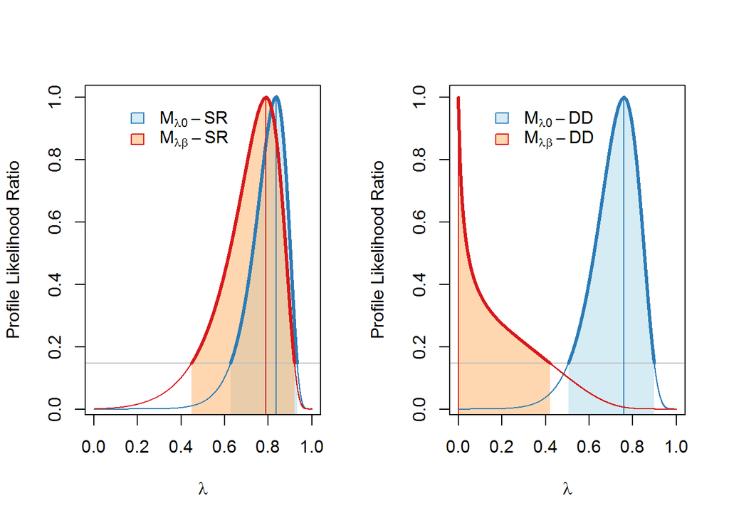

```r
Res1 <- pl_tMl0
Res2 <- pl_tMlb
yv <- exp(Res1-max(Res1))
plot(lam, yv, type="n", lwd=1, ylim=exp(c(2*Crit, 0)),
    xlab=expression(lambda), ylab="Profile Likelihood Ratio")
tmp1 <- splinefun(lam, yv)(ltmp)
i1 <- tmp1 > exp(Crit)
yv <- exp(Res2-max(Res2))
tmp2 <- splinefun(lam, yv)(ltmp)
i2 <- tmp2 > exp(Crit)
polygon(c(ltmp[i1], rev(ltmp[i1])),
    c(tmp1[i1], rep(-1, sum(i1))),
    col=Col2, border=NA)
polygon(c(ltmp[i2], rev(ltmp[i2])),
    c(tmp2[i2], rep(-1, sum(i2))),
    col=Col4, border=NA)
abline(h=exp(Crit), col="grey")
lines(ltmp, tmp1, col=Col1, lwd=1)
lines(ltmp[i1], tmp1[i1], col=Col1, lwd=3)
lines(rep(ltmp[which.max(tmp1)], 2), c(1, -1), col=Col1)
lines(ltmp, tmp2, col=Col3, lwd=1)
lines(ltmp[i2], tmp2[i2], col=Col3, lwd=3)
lines(rep(ltmp[which.max(tmp2)], 2), c(1, -1), col=Col3)
box()
legend(0.1, 1, bty="n", border=c(Col1, Col3), fill=c(Col2, Col4), pt.cex=2, pt.lwd=2,
    legend=c(expression(M[lambda*0]-DD), expression(M[lambda*beta]-DD)))
```

```r
round(c(Max_Ml0=ltmp[which.max(tmp1)], CI=range(ltmp[i1])), 3)
```

```
## Max_Ml0     CI1     CI2
##   0.759   0.504   0.899
```

```r
round(c(Max_Mlx=ltmp[which.max(tmp2)], CI=range(ltmp[i2])), 3)
```

```
## Max_Mlx     CI1     CI2
##   0.000   0.000   0.421
```

```r
par(op)
#dev.off()
```

### Bootstrap distributions of lambda

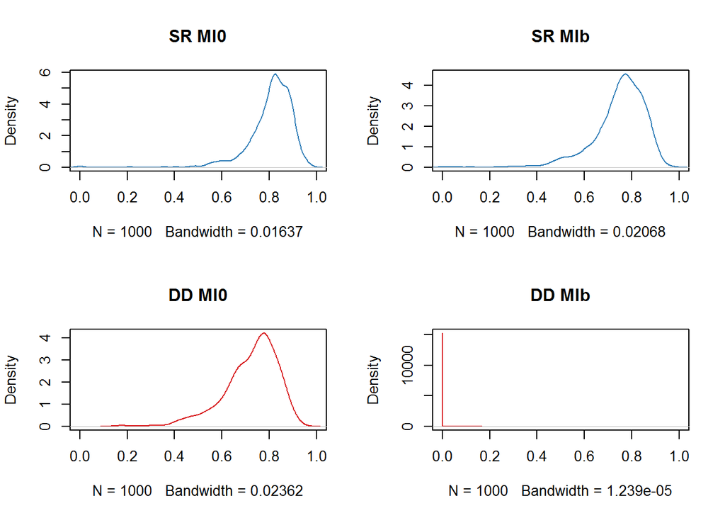

```r
#pdf("FigPB.pdf", width=10, height=10)
op <- par(mfrow=c(2,2))
plot(density(pb_pMl0$estimates[,"lambda"]),
    xlim=c(0,1), main="SR Ml0", col=Col1)
plot(density(pb_pMlb$estimates[,"lambda"]),
    xlim=c(0,1), main="SR Mlb", col=Col1)
plot(density(pb_tMl0$estimates[,"lambda"]),
    xlim=c(0,1), main="DD Ml0", col=Col3)
plot(density(pb_tMlb$estimates[,"lambda"]),
    xlim=c(0,1), main="DD Mlb", col=Col3)
```

```r
par(op)
#dev.off()
```

### LOO cross validation plots

```r
pdf("Fig2.pdf", width=12.75, height=7)
op <- par(mfrow=c(1,2))

Max <- 0.7
D <- as.matrix(dist(prp))
diag(D) <- Inf
D <- apply(D, 1, min)
plot(prp, xaxs = "i", yaxs = "i", type="n", asp=1,
    ylim=c(0, Max), xlim=c(0, Max),
    xlab="Time-removal SR Estimate (/min)",
    ylab="LOO SR Estimate (/min)")
abline(0,2,lty=2, col="grey")
abline(0,1/2,lty=2, col="grey")
abline(0,1.5,lty=2, col="grey")
abline(0,1/1.5,lty=2, col="grey")
abline(0,1,lty=1, col=1)
r0 <- size_fun(x$MaxFreqkHz, 0.2*Max/50, Max/50)
draw.ellipse(prp[,1], prp[,2], r0, r0,
    border=c(Col1,Col3)[as.integer(x$Mig2)])
segments(prp[,1], PIp[,1], prp[,1], PIp[,2],
    col=c(Col1,Col3)[as.integer(x$Mig2)], lwd=1)
box()
legend("topleft", pch=21, col=c(Col1,Col3),
    pt.cex=c(2,2), bty="n",
    legend=c("Migrant", "Resident"))
r <- seq(0.2*Max/50, Max/50, len=5)
draw.ellipse(rep(0.06, 5), 0.55+r-max(r), r, r, border=1)
text(c(0.09, 0.06, 0.06), c(0.61, 0.52, 0.58),
    c("Song Pitch (kHz)",round(range(x$MaxFreqkHz),1)),
    cex=c(1,0.75,0.75))
text(0.9*Max, 0.05*Max, expression(M[lambda*beta]-SR))
#Ti <- D > 0.03
#Ti <- D > 0.03 | (prp[,1]/prp[,2] > 2 | prp[,1]/prp[,2] < 1/2)
Ti <- D > 0.03 | (prp[,1]/prp[,2] > 3.2 | prp[,1]/prp[,2] < 1/3.2)
text(prp[,1], prp[,2], ifelse(Ti, as.character(x$spp), NA),
    cex=0.6, pos=3, col=1)

Max <- 100*2.1
D <- as.matrix(dist(prt))
diag(D) <- Inf
D <- apply(D, 1, min)
plot(100*prt, xaxs = "i", yaxs = "i", type="n", asp=1,
    ylim=c(0, Max), xlim=c(0, Max),
    xlab="Distance-sampling DD Estimate (m)",
    ylab="LOO DD Estimate (m)")
abline(0,2,lty=2, col="grey")
abline(0,1/2,lty=2, col="grey")
abline(0,1.5,lty=2, col="grey")
abline(0,1/1.5,lty=2, col="grey")
abline(0,1,lty=1, col=1)
r0 <- size_fun(x$logmass, 0.2*Max/50, Max/50)
draw.ellipse(100*prt[,1], 100*prt[,2], r0, r0,
    border=c(Col1,Col3)[as.integer(x$Hab2)])
segments(100*prt[,1], 100*PIt[,1], 100*prt[,1], 100*PIt[,2],
    col=c(Col1,Col3)[as.integer(x$Hab2)], lwd=1)
box()
legend("topleft", pch=21, col=c(Col1,Col3), pt.cex=c(2,2), bty="n",
    legend=c("Habitat: Closed", "Habitat: Open"))
r <- seq(0.2*Max/50, Max/50, len=5)
S <- Max/0.7
draw.ellipse(S*rep(0.06, 5), S*0.55+r-max(r), r, r, border=1)
text(S*c(0.09, 0.06, 0.06), S*c(0.61, 0.52, 0.58),
    c("Body Mass (g)",round(range(x$logmass),1)),
    cex=c(1,0.75,0.75))
text(0.9*Max, 0.05*Max, expression(M[0*beta]-DD))
Ti <- D > 0.09 | (prt[,1]/prt[,2] > 2 | prt[,1]/prt[,2] < 1/2)
text(100*prt[,1], 100*prt[,2], ifelse(Ti, as.character(x$spp), NA),
    cex=0.6, pos=3, col=1)

par(op)
dev.off()
```

The percent of species where prediction intervals overlapped the estimated values:

```r
library(intrval)
## SR
## # species with overlapping PI
sum(prp[,"obs"] %[]% PIp)
```

```
## [1] 25
```

```r
## # species with >150% or <66% of original estimates
sum((prp[,"pred"]/prp[,"obs"]) %)(% c(3/2, 2/3))
```

```
## [1] 34
```

```r
## # species with >200% or <50% of original estimates
sum((prp[,"pred"]/prp[,"obs"]) %)(% c(2, 1/2))
```

```
## [1] 12
```

```r
## DD
## % species with overlapping PI
sum(prt[,"obs"] %[]% PIt)
```

```
## [1] 45
```

```r
## # species with >150% or <66% of original estimates
sum((prt[,"pred"]/prt[,"obs"]) %)(% c(3/2, 2/3))
```

```
## [1] 7
```

```r
## # species with >200% or <50% of original estimates
sum((prt[,"pred"]/prt[,"obs"]) %)(% c(2, 1/2))
```

```
## [1] 3
```

### Mapping continuous traits on the tree

We need to hack the `phytools::contMap` function to produce non-rainbow colors. Then we produce trees for the continuous traits.

```r
library(phytools)
```

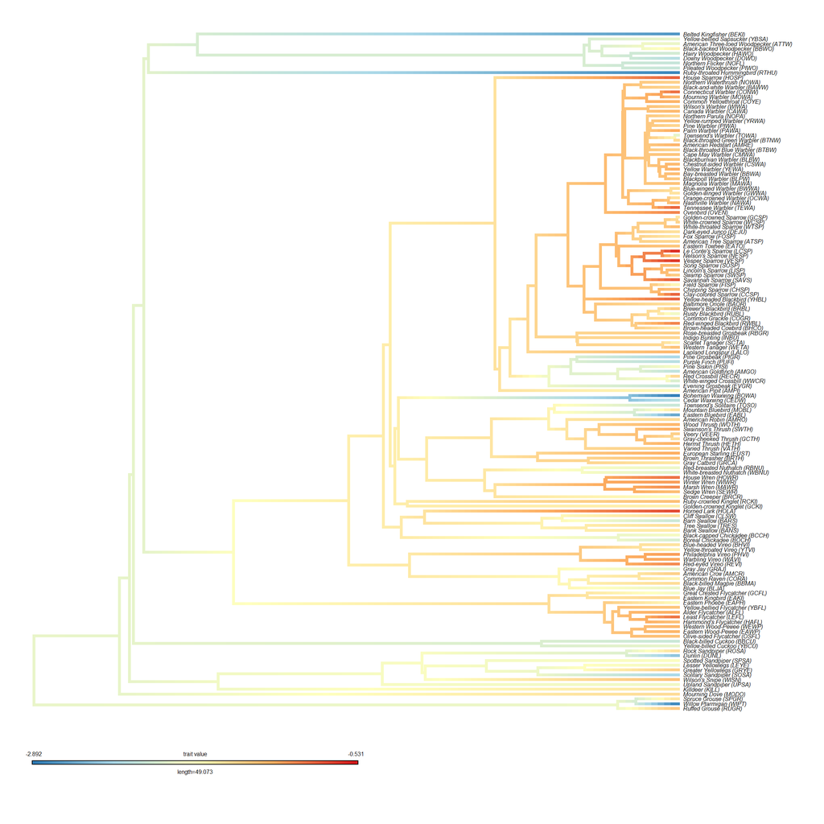

```r
contMap2 <-
function (tree, x, res = 100, fsize = NULL, ftype = NULL, lwd = 4,
    legend = NULL, lims = NULL, outline = TRUE, sig = 3, type = "phylogram",
    direction = "rightwards", plot = TRUE, col_fun=rainbow, ...)
{
    if (!inherits(tree, "phylo"))
        stop("tree should be an object of class \"phylo\".")
    if (hasArg(mar))
        mar <- list(...)$mar
    else mar <- rep(0.3, 4)
    if (hasArg(offset))
        offset <- list(...)$offset
    else offset <- NULL
    if (hasArg(method))
        method <- list(...)$method
    else method <- "fastAnc"
    if (hasArg(hold))
        hold <- list(...)$hold
    else hold <- TRUE
    if (hasArg(leg.txt))
        leg.txt <- list(...)$leg.txt
    else leg.txt <- "trait value"
    h <- max(nodeHeights(tree))
    steps <- 0:res/res * max(h)
    H <- nodeHeights(tree)
    if (method == "fastAnc")
        a <- fastAnc(tree, x)
    else if (method == "anc.ML") {
        fit <- anc.ML(tree, x)
        a <- fit$ace
        if (!is.null(fit$missing.x))
            x <- c(x, fit$missing.x)
    }
    else if (method == "user") {
        if (hasArg(anc.states))
            anc.states <- list(...)$anc.states
        else {
            cat("No ancestral states have been provided. Using states estimated with fastAnc.\n\n")
            a <- fastAnc(tree, x)
        }
        if (length(anc.states) < tree$Nnode) {
            nodes <- as.numeric(names(anc.states))
            tt <- tree
            for (i in 1:length(nodes)) {
                M <- matchNodes(tt, tree, method = "distances")
                ii <- M[which(M[, 2] == nodes[i]), 1]
                tt <- bind.tip(tt, nodes[i], edge.length = 0,
                  where = ii)
            }
            a <- fastAnc(tt, c(x, anc.states))
            M <- matchNodes(tree, tt, method = "distances")
            a <- a[as.character(M[, 2])]
            names(a) <- M[, 1]
        }
        else {
            if (is.null(names(anc.states)))
                names(anc.states) <- 1:tree$Nnode + Ntip(tree)
            a <- anc.states[as.character(1:tree$Nnode + Ntip(tree))]
        }
    }
    y <- c(a, x[tree$tip.label])
    names(y)[1:Ntip(tree) + tree$Nnode] <- 1:Ntip(tree)
    A <- matrix(y[as.character(tree$edge)], nrow(tree$edge),
        ncol(tree$edge))
    cols <- col_fun(1001)
    names(cols) <- 0:1000
    if (is.null(lims))
        lims <- c(min(y), max(y))
    trans <- 0:1000/1000 * (lims[2] - lims[1]) + lims[1]
    names(trans) <- 0:1000
    tree$maps <- vector(mode = "list", length = nrow(tree$edge))
    for (i in 1:nrow(tree$edge)) {
        XX <- cbind(c(H[i, 1], steps[intersect(which(steps >
            H[i, 1]), which(steps < H[i, 2]))]), c(steps[intersect(which(steps >
            H[i, 1]), which(steps < H[i, 2]))], H[i, 2])) - H[i,
            1]
        YY <- rowMeans(XX)
        if (!all(YY == 0)) {
            b <- vector()
            for (j in 1:length(YY)) b[j] <- (A[i, 1]/YY[j] +
                A[i, 2]/(max(XX) - YY[j]))/(1/YY[j] + 1/(max(XX) -
                YY[j]))
        }
        else b <- A[i, 1]
        d <- sapply(b, phytools:::getState, trans = trans)
        tree$maps[[i]] <- XX[, 2] - XX[, 1]
        names(tree$maps[[i]]) <- d
    }
    tree$mapped.edge <- phytools:::makeMappedEdge(tree$edge, tree$maps)
    tree$mapped.edge <- tree$mapped.edge[, order(as.numeric(colnames(tree$mapped.edge)))]
    class(tree) <- c("simmap", setdiff(class(tree), "simmap"))
    xx <- list(tree = tree, cols = cols, lims = lims)
    class(xx) <- "contMap"
    if (plot)
        phytools:::plot.contMap(xx, fsize = fsize, ftype = ftype, lwd = lwd,
            legend = legend, outline = outline, sig = sig, type = type,
            mar = mar, direction = direction, offset = offset,
            hold = hold, leg.txt = leg.txt)
    invisible(xx)
}

## log singing rates
contMap2(tre, structure(d2$logphi, .Names=NAMES),
    fsize=0.5, outline=FALSE, col_fun=col_fun)
```

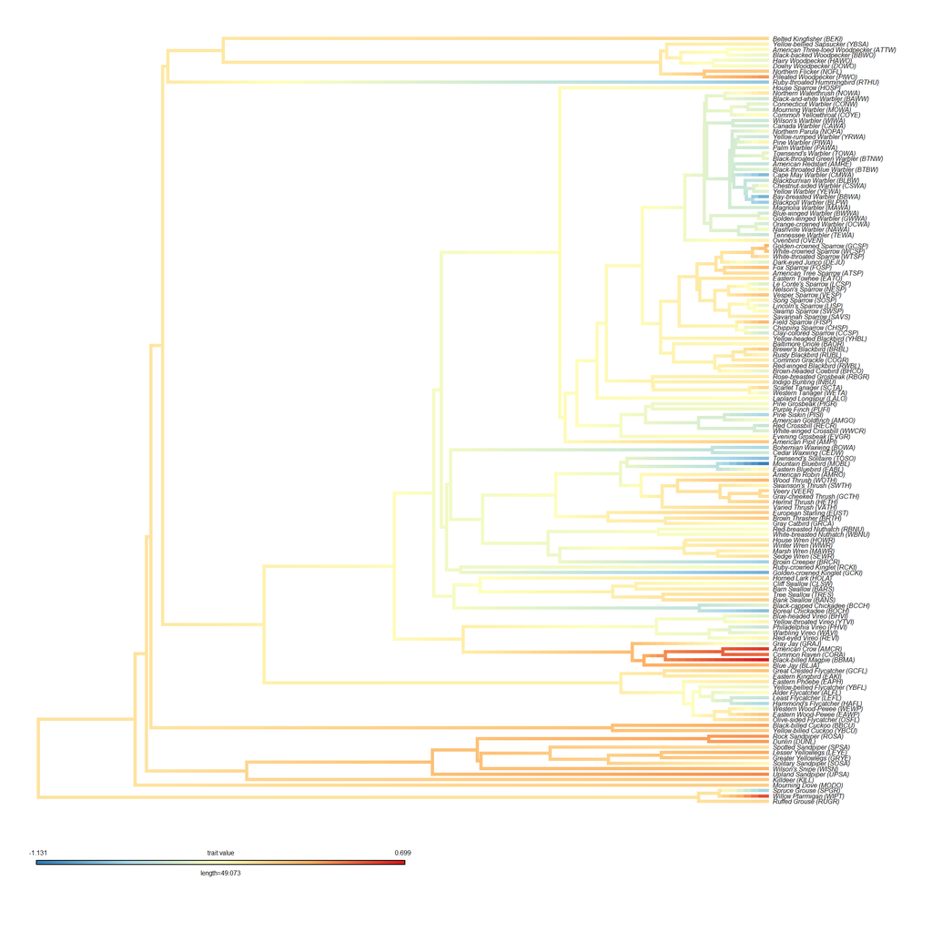

```r
## log detection distances
contMap2(tre, structure(d2$logtau, .Names=NAMES),
    fsize=0.5, outline=FALSE, col_fun=col_fun)
```

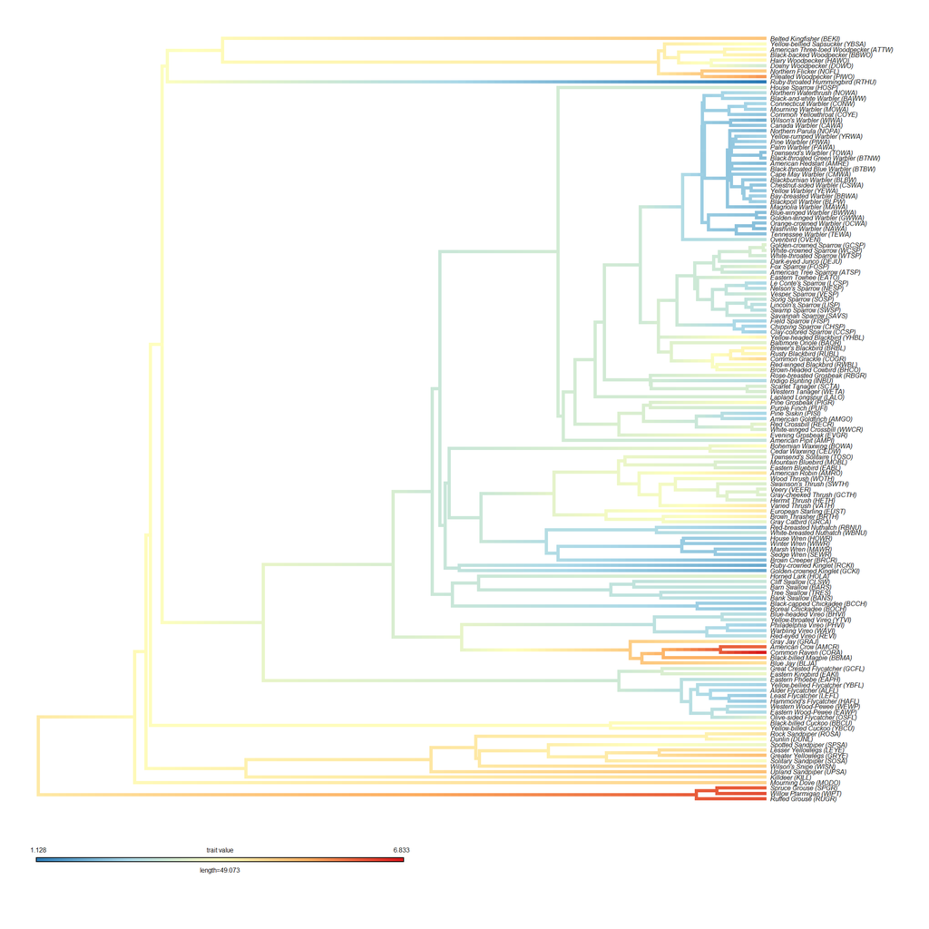

```r
## log body mass
contMap2(tre, structure(d2$logmass, .Names=NAMES),
    fsize=0.5, outline=FALSE, col_fun=col_fun)
```

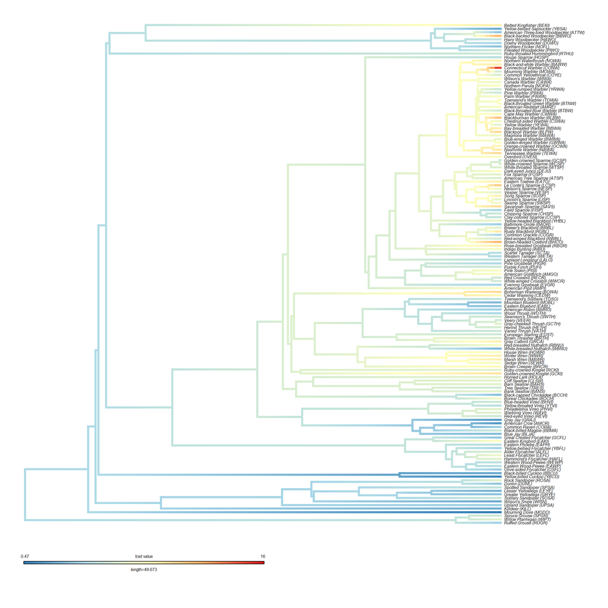

```r
## pitch
contMap2(tre, structure(d2$MaxFreqkHz, .Names=NAMES),
    fsize=0.5, outline=FALSE, col_fun=col_fun)
```

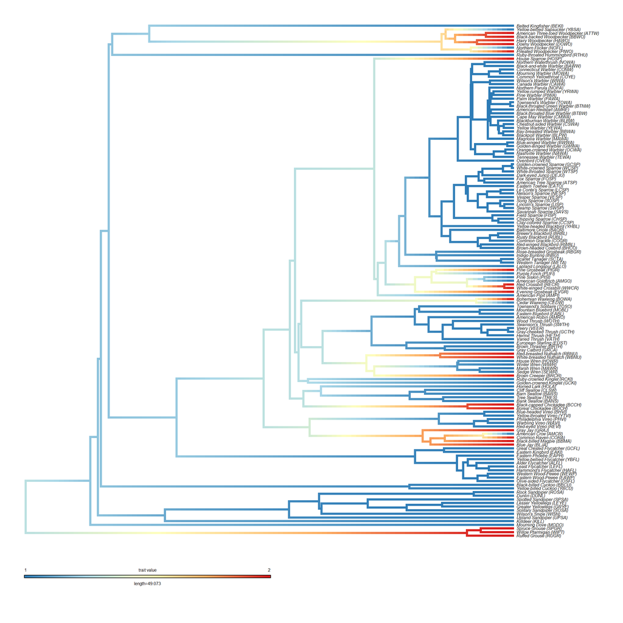

```r
## migratory status
contMap2(tre, structure(d2$Mig2, .Names=NAMES),
    fsize=0.5, outline=FALSE, col_fun=col_fun)
```

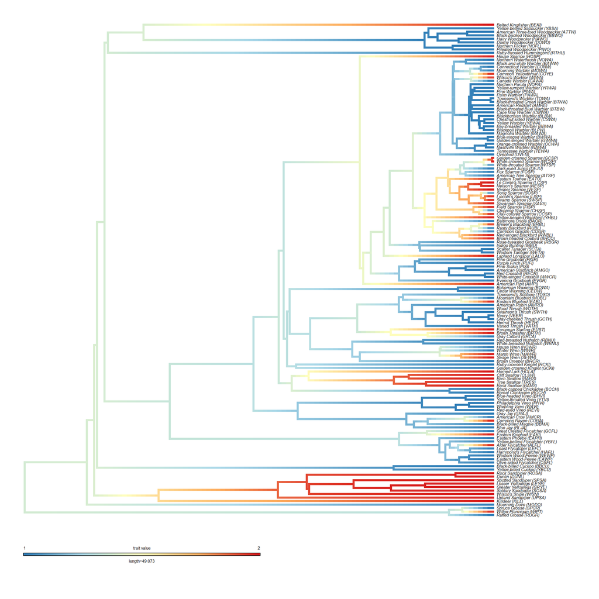

```r
## habitat associations
contMap2(tre, structure(d2$Hab2, .Names=NAMES),
    fsize=0.5, outline=FALSE, col_fun=col_fun)
```